# 06_transcriptomics

### 6.5. Exploring DEG

- Got 918 genes in this list, but 755 only have |b|>1

```r
ct_table <- sleuth_results(ct_so, 'typethallus')
ct_sig <- ct_table %>% tibble::as_tibble() %>%
  filter( qval <= 0.05) %>%
  arrange(desc(b)) %>% mutate(change = case_when(b > 1 ~"thallus",
                                                 b< -1 ~ "culture",
                                                 b<=1&b>=-1 ~ "lowFC"))

table(ct_sig$change)
```

```
##
## culture   lowFC thallus
##     570     163     185
```

- Checking the annotations.

```r
ct_sig <- ct_sig %>% left_join(ann,by=c("target_id"="TranscriptID"))

#ct_sig%>%
 # kable(format = "html", col.names = colnames(ct_sig)) %>%
 # kable_styling() %>%
  #kableExtra::scroll_box(width = "100%", height = "400px")
```

- 6 are secreted, including two ferritin domains, one of them upregulated in lichen. Cupin and Cupredoxin upregulated in culture

```r
ct_sig %>% filter(target_id %in% secretome$TranscriptID) %>%
  kable(format = "html", col.names = colnames(ct_sig)) %>%
  kable_styling() %>%
  kableExtra::scroll_box(width = "100%", height = "400px")
```

target_id

pval

qval

b

se_b

mean_obs

var_obs

tech_var

sigma_sq

smooth_sigma_sq

final_sigma_sq

change

GeneID

Feature

Contig

Start

Stop

Strand

Name

Product

Alias.Synonyms

EC_number

BUSCO

PFAM

InterPro

COG

GO.Terms

Protease

CAZyme

GTX0536PRED_008762-T1

0.0000000

0.0000000

2.2684043

0.3195231

4.917541

1.2077020

0.0112958

0.0831630

0.2114569

0.2114569

thallus

GTX0536PRED_008762

mRNA

GTX0536_11

2061780

2062465

hypothetical protein

NA

NA

NA

GTX0536PRED_011783-T1

0.0037330

0.0144084

1.8440436

0.6359032

7.879562

1.5359679

0.0027154

0.8795527

0.1250483

0.8795527

thallus

GTX0536PRED_011783

mRNA

GTX0536_17

2253058

2254543

hypothetical protein

NA

NA

PF13668

IPR009078 Ferritin-like superfamily

NA

GTX0536PRED_009543-T1

0.0043587

0.0163856

-0.8877712

0.3113936

6.019226

0.3623632

0.0171217

0.1944404

0.0982324

0.1944404

lowFC

GTX0536PRED_009543

mRNA

GTX0536_12

3042971

3047046

hypothetical protein

NA

NA

PF13668

NA

GTX0536PRED_010618-T1

0.0045308

0.0168837

-3.4066487

1.2001045

2.805606

4.5447616

0.0730348

2.1633051

3.0693307

3.0693307

culture

GTX0536PRED_010618

mRNA

GTX0536_15

136062

137325

hypothetical protein

NA

NA

PF02298

IPR003245 Phytocyanin domain;IPR008972 Cupredoxin;IPR039391 Phytocyanin

NA

GO_function: GO:0009055 - electron transfer activity [Evidence IEA]

GTX0536PRED_003076-T1

0.0000664

0.0003581

-4.8456066

1.2147443

2.097858

8.0204372

0.2432222

2.9762771

1.8962915

2.9762771

culture

GTX0536PRED_003076

mRNA

GTX0536_3

3915339

3916542

hypothetical protein

NA

NA

PF00190

IPR006045 Cupin 1;IPR011051 RmlC-like cupin domain superfamily;IPR014710 RmlC-like jelly roll fold

NA

GTX0536PRED_000902-T1

0.0000000

0.0000000

-7.6234021

0.5465273

1.385962

12.6799885

0.0000240

0.0000621

0.6516680

0.6516680

culture

GTX0536PRED_000902

mRNA

GTX0536_1

5293099

5295096

hypothetical protein

NA

NA

NA

Save the table

```r
ct_sig <- ct_sig %>% mutate(is_secreted = if_else(target_id %in% secretome$TranscriptID,"Yes","No"))
write.table(ct_sig,"../results/dge_culture_thallus.txt",row.names = F,quote = F,col.names = T,sep="\t")
```

### 6.6. Enriched InterPro and GO in lichen

```r
library(clusterProfiler)
```

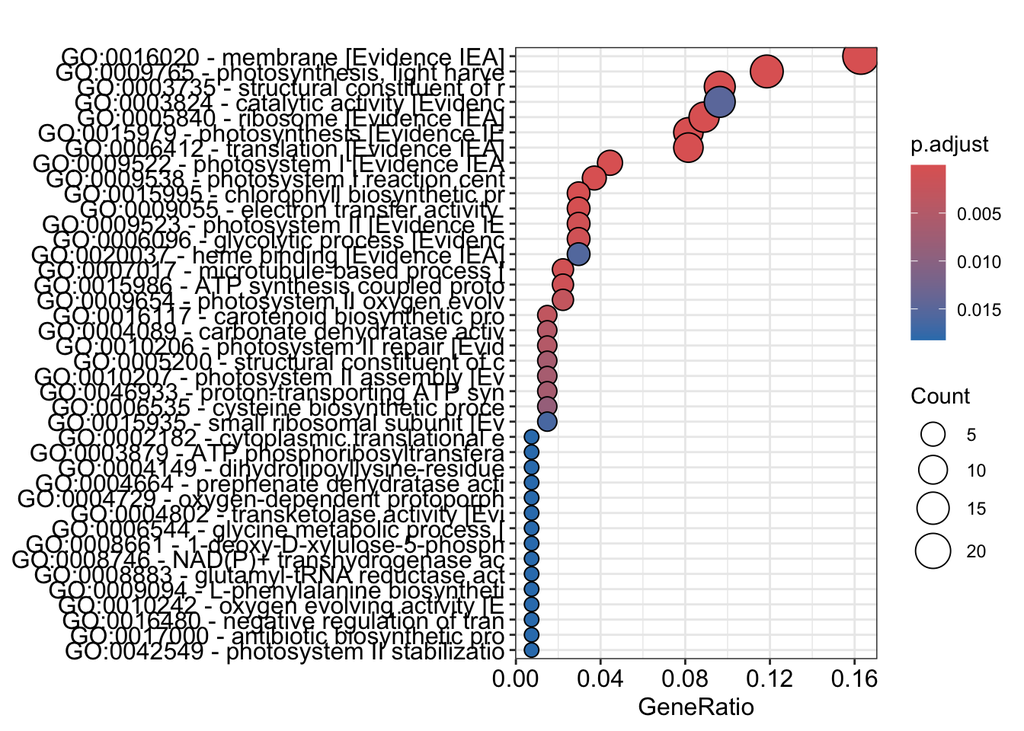

```r
###make table with GO annotations
go_df <- ann %>% select(TranscriptID,GO.Terms) %>%
  mutate(GO.Terms = strsplit(GO.Terms, ";")) %>%
        unnest(GO.Terms) %>%
  mutate(GO.Terms=sub(".*? ", "", GO.Terms),
         short_term = substr(GO.Terms, 1,40))

go_data <- list(
    term2protein = data.frame(
                        term = go_df$GO.Terms,
                        gene = go_df$TranscriptID
                        ),
    term2name = data.frame(
                        term = go_df$GO.Terms,
                        name = go_df$short_term
                        ),

    universe = unique(as.character(go_df$TranscriptID))
)

### select genes upregulated in lichens and order them by fold change
geneList1 = ct_sig$b[ct_sig$change=="thallus"]
names(geneList1) = ct_sig$target_id[ct_sig$change=="thallus"]
geneList1 = sort(geneList1, decreasing = F)
geneList1 <- names(geneList1)

###enrichment analysis
enrich1<-clusterProfiler::enricher(geneList1,
    pAdjustMethod = "none",
    minGSSize = 1,
    maxGSSize = 2000,
    qvalueCutoff = 1,
    universe=go_data$universe,
    TERM2GENE=go_data$term2protein,
    TERM2NAME=go_data$term2name)

enrichplot::dotplot(enrich1,showCategory=40,label_format=40)
```

- Plot as graph

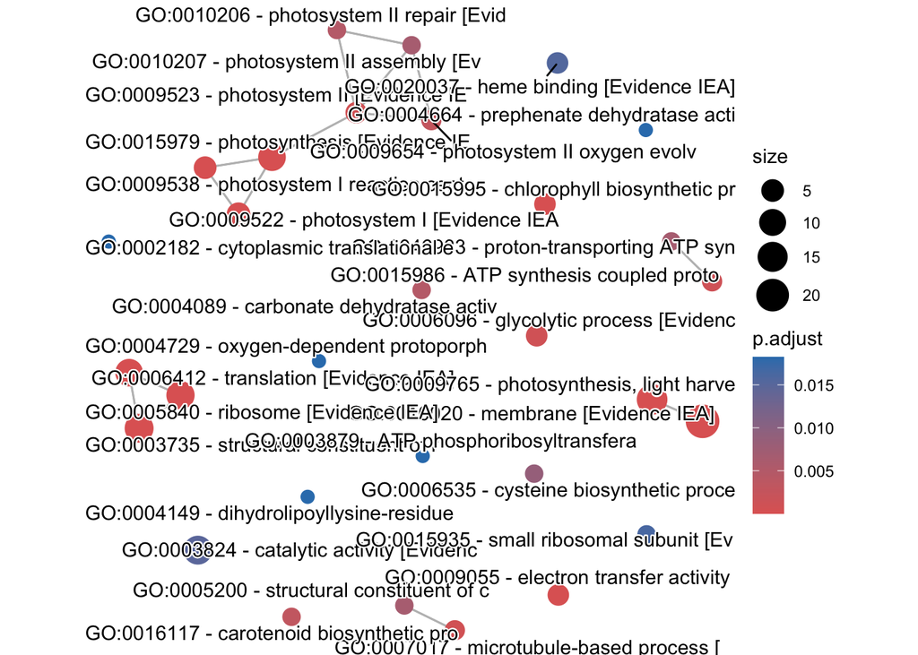

```r
enrich1_pairwise<-enrichplot::pairwise_termsim(enrich1)
enrichplot::emapplot(enrich1_pairwise,layout="nicely",label_group_style = "ggforce")
```

```r
pdf(file="../results/thallus_upr_go.pdf",width=10,height=8)
enrichplot::emapplot(enrich1_pairwise,layout="nicely",label_group_style = "ggforce")
dev.off()
```

- Now, InterPro domains

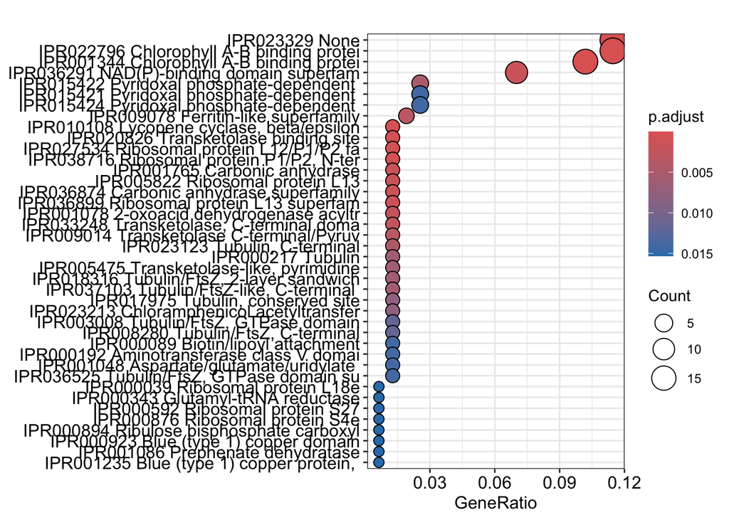

```r
ips_df <-ann %>% select(TranscriptID,InterPro) %>%
  mutate(InterPro_new = strsplit(InterPro, ";")) %>%
        unnest(InterPro_new) %>%
  mutate(short_term = substr(InterPro_new, 1,40))


ips_data <- list(
    term2protein = data.frame(
                        term = ips_df$InterPro_new,
                        gene = ips_df$TranscriptID
                        ),
    term2name = data.frame(
                        term = ips_df$InterPro_new,
                        name = ips_df$short_term
                        ),

    universe = unique(as.character(ips_df$TranscriptID))
)

###enrichment analysis
enrich2<-clusterProfiler::enricher(geneList1,
    pAdjustMethod = "none",
    minGSSize = 1,
    maxGSSize = 2000,
    qvalueCutoff = 1,
    universe=ips_data$universe,
    TERM2GENE=ips_data$term2protein,
    TERM2NAME=ips_data$term2name)

enrichplot::dotplot(enrich2,showCategory=40,label_format=40)
```

- Plot as graph

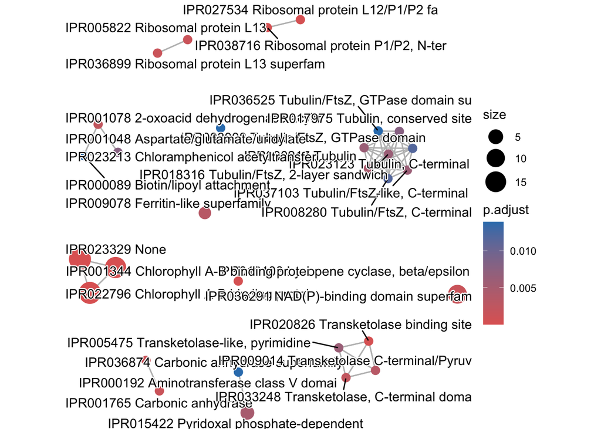

```r
enrich2_pairwise<-enrichplot::pairwise_termsim(enrich2)
enrichplot::emapplot(enrich2_pairwise,layout="nicely",label_group_style = "ggforce")
```

```r
pdf(file="../results/thallus_upr.pdf",width=10,height=8)
enrichplot::emapplot(enrich2_pairwise,layout="nicely",label_group_style = "ggforce")
dev.off()
```

### 6.7. Enriched InterPro and GO in culture

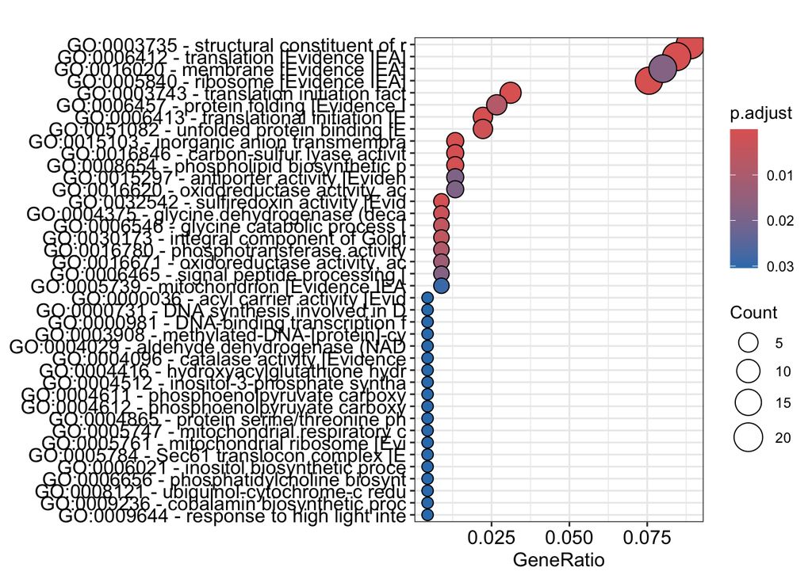

```r
library(clusterProfiler)
library(enrichplot)
### select genes upregulated in lichens and order them by fold change
geneList3 = ct_sig$b[ct_sig$change=="culture"]
names(geneList3) = ct_sig$target_id[ct_sig$change=="culture"]
geneList3 = sort(geneList3, decreasing = T)
geneList3 <- names(geneList3)

###enrichment analysis
enrich3<-clusterProfiler::enricher(geneList3,
    pAdjustMethod = "none",
    minGSSize = 1,
    maxGSSize = 2000,
    qvalueCutoff = 1,
    universe=go_data$universe,
    TERM2GENE=go_data$term2protein,
    TERM2NAME=go_data$term2name)

enrichplot::dotplot(enrich3,showCategory=40,label_format=40)
```

- Plot as graph

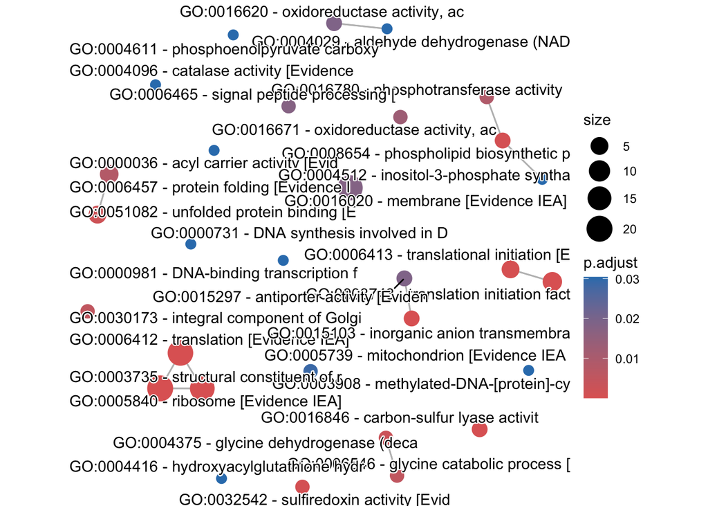

```r
enrich3_pairwise<-enrichplot::pairwise_termsim(enrich3)
enrichplot::emapplot(enrich3_pairwise,layout="nicely")
```

```r
pdf(file="../results/culture_upr_go.pdf",width=10,height=8)
enrichplot::emapplot(enrich3_pairwise,layout="nicely",label_group_style = "ggforce")
dev.off()
```

- Now, InterPro domains

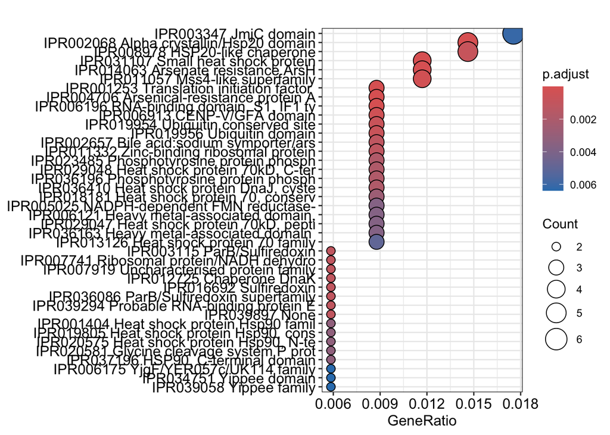

```r
###enrichment analysis
enrich4<-clusterProfiler::enricher(geneList3,
    pAdjustMethod = "none",
    minGSSize = 1,
    maxGSSize = 2000,
    qvalueCutoff = 1,
    universe=ips_data$universe,
    TERM2GENE=ips_data$term2protein,
    TERM2NAME=ips_data$term2name)

enrichplot::dotplot(enrich4,showCategory=40,label_format=40)
```

- Plot as graph

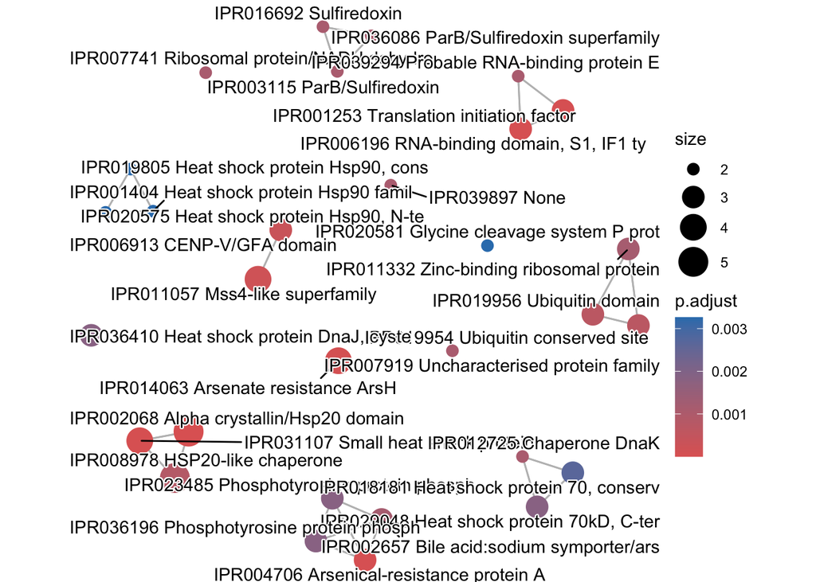

```r
enrich4_pairwise<-enrichplot::pairwise_termsim(enrich4)
enrichplot::emapplot(enrich4_pairwise,layout="nicely")
```

```r
pdf(file="../results/culture_upr.pdf",width=10,height=8)
enrichplot::emapplot(enrich4_pairwise,layout="nicely",label_group_style = "ggforce")
dev.off()
```